# statistical_analysis_16SrRNA

Maggie Sogin

Oct 13 2026

# 1 Set up working space

### 1.0.1 Read in packages

```r
#load in packages and print versions
packages <- c("tidyverse", "ggplot2", "vegan", "phyloseq", "microbiome",
               "ranacapa", "microViz", "patchwork", "pairwiseAdonis", "pheatmap","ALDEx2","emmeans")
invisible(lapply(packages, function(pkg) {
  library(pkg, character.only = TRUE)
  cat(pkg, ":", as.character(packageVersion(pkg)), "\n")
}))
```

```
## tidyverse : 2.0.0
## ggplot2 : 4.0.3
```

```
## vegan : 2.7.5
## phyloseq : 1.56.0
```

[output not shown]

```
## microbiome : 1.34.0
## ranacapa : 0.1.0
```

```
## microViz version 0.13.1 - Copyright (C) 2021-2026 David Barnett
## ! Website: https://david-barnett.github.io/microViz
## ✔ Useful?  For citation details, run: `citation("microViz")`
## ✖ Silence? `suppressPackageStartupMessages(library(microViz))`
```

```
## microViz : 0.13.1
## patchwork : 1.3.2
```

```
## pairwiseAdonis : 0.4.1
## pheatmap : 1.0.13
```

```
## ALDEx2 : 1.44.0
```

```
## Caution: You lose important information if you filter this package's results.
## See '? untidy'
```

```
## emmeans : 2.0.3
```

### 1.0.2 Set up plotting conditions

```r
#set up plotting conditions
trt<-c("FASW","ABS","labrenzia","ruegeria","vibrio","ISOABC")
myPal<-c('grey60','black','#A6CEE3','#1F78B4','#B2DF8A','violet')
names(myPal) = trt

dpis<-c("-1","0","1","4","14","21")
shpPal<-c(0,15,11,13,5,1)
names(shpPal) = dpis

dpiPal<-c('black','gray30','seashell','seashell2','seashell3','seashell4')
names(dpiPal) <- c('-1','0','1','4','14','21')

theme_new<- theme_bw() + theme(panel.grid.major = element_line(color='gray90'), panel.grid.minor = element_line(color='gray90'), text= element_text(size = 15))
```

# 2 Load and Manipulate Data

set paths

```r
path.in<-"../../data/16S"
path.out<-"../../output/16S"
```

```r
ps.exp<-readRDS(file.path(path.in,'ps.exp.samples.rds'))
ps.exp
```

```
## phyloseq-class experiment-level object
## otu_table()   OTU Table:         [ 657 taxa and 111 samples ]
## sample_data() Sample Data:       [ 111 samples by 11 sample variables ]
## tax_table()   Taxonomy Table:    [ 657 taxa by 7 taxonomic ranks ]
## phy_tree()    Phylogenetic Tree: [ 657 tips and 655 internal nodes ]
## refseq()      DNAStringSet:      [ 657 reference sequences ]
```

fix taxa names

```r
ps.exp<-ps.exp %>%tax_fix()
```

## 2.1 Sample sizes

```r
samps.sizes<-data.frame(sample_data(ps.exp)) %>% group_by(treatment, timepoint) %>% summarise(count=length(sample.names))
```

```
## `summarise()` has regrouped the output.
## ℹ Summaries were computed grouped by treatment and timepoint.
## ℹ Output is grouped by treatment.
## ℹ Use `summarise(.groups = "drop_last")` to silence this message.
## ℹ Use `summarise(.by = c(treatment, timepoint))` for per-operation grouping
##   (`?dplyr::dplyr_by`) instead.
```

```r
samps.sizes %>% arrange(treatment, timepoint,count)
```

```
## # A tibble: 27 × 3
## # Groups:   treatment [6]
##    treatment timepoint    count
##    <fct>     <chr>        <int>
##  1 FASW      14dpi            4
##  2 FASW      1dpi             4
##  3 FASW      21dpi            4
##  4 FASW      4dpi             4
##  5 FASW      post_ABS         4
##  6 FASW      post_priming     4
##  7 ABS       14dpi            4
##  8 ABS       1dpi             4
##  9 ABS       21dpi            4
## 10 ABS       4dpi             3
## # ℹ 17 more rows
```

## 2.2 Normalize phyloseq object

```r
ps.exp.agg<-ps.exp %>% tax_agg("Species")
```

## 2.3 clr norm

```r
ps.clr<-ps.exp.agg %>%  tax_transform(trans="clr")
```

## 2.4 rel abund norm

```r
ps.relAbund<-ps.exp.agg %>%
  tax_transform(trans="compositional")
```

## 2.5 rarefy data

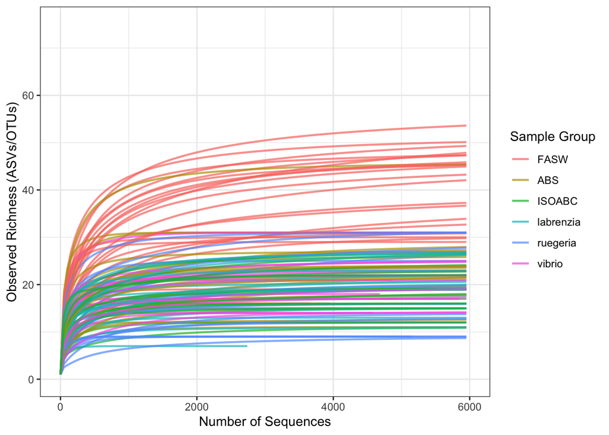

```r
# 1. Extract OTU table and metadata
otu_mat <- as.data.frame(otu_table(ps.exp.agg))
metadata <- as(sample_data(ps.exp.agg), "data.frame")

# 2. Calculate rarefaction for each sample
rare_out <- rarecurve(otu_mat, step = 50, tidy = TRUE)
# 3. Merge rarefaction data with your sample metadata
rare_data <- rare_out %>%
    dplyr::rename(SampleID = Site, Reads = Sample, Observed_ASVs = Species) %>%
    left_join(rownames_to_column(metadata, var = "SampleID"), by = "SampleID")

# 4. Plot using ggplot2, coloring by your group (e.g., TreatmentGroup)
ggplot(rare_data, aes(x = Reads, y = Observed_ASVs, group = SampleID, color = treatment)) +
  geom_line(linewidth = 0.8, alpha = 0.7) +
  theme_bw() +
  labs(
    x = "Number of Sequences",
    y = "Observed Richness (ASVs/OTUs)",
    color = "Sample Group"
  ) +
  xlim(0,6000) + ylim(0,75)
```

```r
set.seed(200)
ps.exp.agg.reduced<-prune_samples(sample_sums(ps.exp.agg) >=4900, ps.exp.agg)
samps.sizes<-data.frame(sample_data(ps.exp.agg.reduced)) %>% group_by(treatment, timepoint) %>% summarise(count=length(sample.names))
```

```
## `summarise()` has regrouped the output.
## ℹ Summaries were computed grouped by treatment and timepoint.
## ℹ Output is grouped by treatment.
## ℹ Use `summarise(.groups = "drop_last")` to silence this message.
## ℹ Use `summarise(.by = c(treatment, timepoint))` for per-operation grouping
##   (`?dplyr::dplyr_by`) instead.
```

```r
samps.sizes %>% arrange(count)
```

```
## # A tibble: 27 × 3
## # Groups:   treatment [6]
##    treatment timepoint count
##    <fct>     <chr>     <int>
##  1 FASW      1dpi          3
##  2 FASW      4dpi          3
##  3 ABS       4dpi          3
##  4 ABS       post_ABS      3
##  5 ISOABC    4dpi          3
##  6 labrenzia 4dpi          3
##  7 vibrio    14dpi         3
##  8 vibrio    1dpi          3
##  9 vibrio    4dpi          3
## 10 FASW      14dpi         4
## # ℹ 17 more rows
```

```r
set.seed(1245)
ps.rare<- rarefy_even_depth(ps.exp.agg.reduced,rngseed = T)
```

```
## `set.seed(TRUE)` was used to initialize repeatable random subsampling.
```

```
## Please record this for your records so others can reproduce.
```

```
## Try `set.seed(TRUE); .Random.seed` for the full vector
```

```
## ...
```

```
## 19OTUs were removed because they are no longer
## present in any sample after random subsampling
```

```
## ...
```

```r
ps.rare
```

```
## phyloseq-class experiment-level object
## otu_table()   OTU Table:         [ 191 taxa and 104 samples ]
## sample_data() Sample Data:       [ 104 samples by 11 sample variables ]
## tax_table()   Taxonomy Table:    [ 191 taxa by 7 taxonomic ranks ]
```

# 3 Priority Effect Analysis

Study design:

Anemones were treated with ABS solutions and then incoculated with one of the following: - Isolate A - Labrenzia - Isolate B - Reugeria - Isolate C - Vibrio - All three isolates - No isolates (ABS control)

There were also anemones that were held in FASW for the entire experiment

Priority effect logic: - Single-strain treatments represent “founder effects” - Does early establishment of one strain alter the final community composition compared to a null model (i.e., ABS or All three strains)? - A strong priority effect = single-strain communities diverge from the community treatment and resist convergence over time.

Evidence for priority effects: - Single strain inoculations remain compositionally distinct at day 21 - PREMANOVA: Significant Time X Treatment Effect -

## 3.1 Beta-diversity analysis

### 3.1.1 rarefied data

#### 3.1.1.1 Ordination

```r
set.seed(1392)

ps.analysis<-ps.rare  %>% ps_filter(dpi != "-1")

#reset factor level variables
sample_data(ps.analysis)$timepoint<-factor(sample_data(ps.analysis)$timepoint,levels=c("post_priming","post_ABS","1dpi","4dpi",'14dpi','21dpi'), ordered=T)
sample_data(ps.analysis)$dpi<-factor(sample_data(ps.analysis)$dpi,levels=c("-1","0","1","4","14","21"), ordered=T)
sample_data(ps.analysis)$treatment<-factor(sample_data(ps.analysis)$treatment,levels=c('FASW', 'ABS' ,'ISOABC', 'labrenzia', 'ruegeria', 'vibrio'), ordered=T)

#run ndms
nmds.mod <- ps.analysis %>%
  dist_calc("bray") %>%
  ord_calc(method = "NMDS") #
```

```
## *** Best solution was not repeated -- monoMDS stopping criteria:
##      1: no. of iterations >= maxit
##     17: stress ratio > sratmax
##      2: scale factor of the gradient < sfgrmin
```

[output not shown]

```r
nmds.mod
```

```
## psExtra object - a phyloseq object with extra slots:
##
## phyloseq-class experiment-level object
## otu_table()   OTU Table:         [ 183 taxa and 100 samples ]
## sample_data() Sample Data:       [ 100 samples by 11 sample variables ]
## tax_table()   Taxonomy Table:    [ 183 taxa by 7 taxonomic ranks ]
##
##
## bray distance matrix of size 100
## 0.4391278 0.6131637 0.5128205 0.7793257 0.6969513 ...
##
## ordination of class: metaMDS monoMDS
## metaMDS(comm = ps.dist)
## Ordination info:
## method = 'NMDS'
```

```r
nmds.mod@ord$stress
```

```
## [1] 0.2352948
```

#####plot

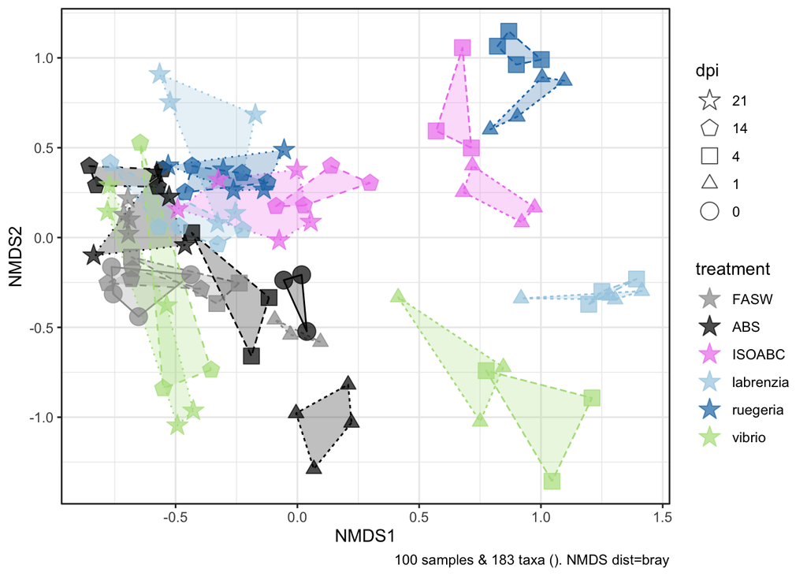

```r
library(ggstar)

n1 <- nmds.mod %>%
ord_plot(shape=NA) +
theme_bw() +
stat_chull(
mapping = aes(colour = treatment, linetype = dpi, fill = treatment),
linewidth = 0.5, alpha = 0.25, show.legend = FALSE) +
geom_star(mapping = aes(color = treatment, fill = treatment, starshape = dpi),
size = 4, alpha = 0.7) +
  scale_fill_manual(values = myPal) +
scale_color_manual(values = myPal) +
scale_starshape_manual(
values = c(
"0" = 15,
"1"= 11,
"4"= 13,
"14" = 5,
"21" = 1
),
guide = guide_legend(reverse = TRUE)
)
n1
```

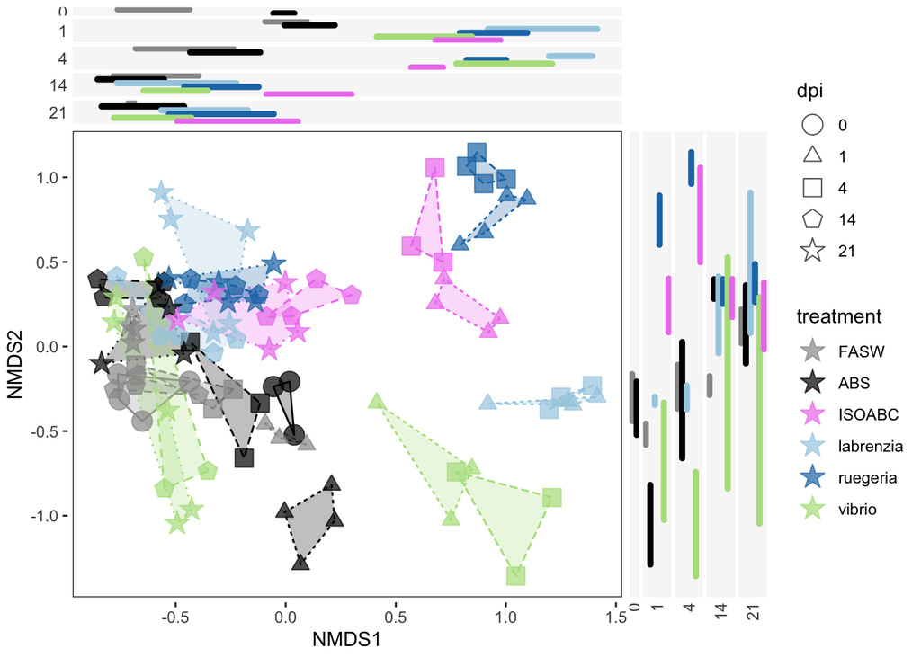

```r
# NMDS site scores + metadata
nmds_scores <- vegan::scores(nmds.mod@ord, display = "sites") %>%
  as.data.frame() %>%
  rownames_to_column("sample_id") %>%
  left_join(data.frame(sample_data(ps.analysis)) %>% rownames_to_column("sample_id"),
            by = "sample_id") %>%
  mutate(dpi = factor(as.character(dpi), levels = c("0", "1", "4", "14", "21"),ordered=T),
         treatment = factor(as.character(treatment), levels = names(myPal)))

# range (min, max) of each axis per treatment x dpi
nmds_ranges <- nmds_scores %>%
  group_by(treatment, dpi) %>%
  summarise(across(c(NMDS1, NMDS2), list(min = min, max = max)), .groups = "drop")

# shared axis limits so the side bars line up with the ordination
x_lims <- range(nmds_scores$NMDS1)
y_lims <- range(nmds_scores$NMDS2)

#dpi_strip <- c("0" = "0 dpi", "1" = "1 dpi", "4" = "4 dpi", "14" = "14 dpi", "21" = "21 dpi")

side_theme <- theme_void() +
  theme(legend.position = "none",
        strip.text = element_text(size = 9, color = "gray30"),
        panel.background = element_rect(fill = "gray97", color = NA),
        panel.spacing = unit(2, "pt"))

# top: NMDS1 range, one band per dpi (0 dpi at top), one line per treatment
nmds1_bar <- ggplot(nmds_ranges, aes(y = fct_rev(treatment), color = treatment)) +
  geom_linerange(aes(xmin = NMDS1_min, xmax = NMDS1_max),
                 linewidth = 1.6, lineend = "round") +
  facet_grid(dpi ~ ., scales = "free_y", space = "free_y", switch = "y") +
  scale_color_manual(values = myPal) +
  coord_cartesian(xlim = x_lims) +
  side_theme +
  theme(strip.text.y.left = element_text(angle = 0, hjust = 1),
        strip.placement = "outside")

# right: NMDS2 range, one band per dpi (0 dpi at left), one line per treatment
nmds2_bar <- ggplot(nmds_ranges, aes(x = treatment, color = treatment)) +
  geom_linerange(aes(ymin = NMDS2_min, ymax = NMDS2_max),
                 linewidth = 1.6, lineend = "round") +
  facet_grid(. ~ dpi, scales = "free_x", space = "free_x", switch = "x") +
  scale_color_manual(values = myPal) +
  coord_cartesian(ylim = y_lims) +
  side_theme +
  theme(strip.text.x.bottom = element_text(angle = 90, hjust = 1),
        strip.placement = "outside")

# main ordination: drop gridlines and the microViz caption, legend 0 -> 21 dpi
n1_clean <- n1 +
  coord_cartesian(xlim = x_lims, ylim = y_lims) +
  guides(starshape = guide_legend(reverse = FALSE)) +
  labs(caption = NULL) +
  theme(panel.grid = element_blank())

# combine: side bars on top (NMDS1) and right (NMDS2)
n1_sidebars <- nmds1_bar + plot_spacer() + n1_clean + nmds2_bar +
  plot_layout(ncol = 2, widths = c(4, 1), heights = c(1, 4), guides = "collect") &
  theme(plot.margin = margin(2, 2, 2, 2))
n1_sidebars
```

facet by timepoint

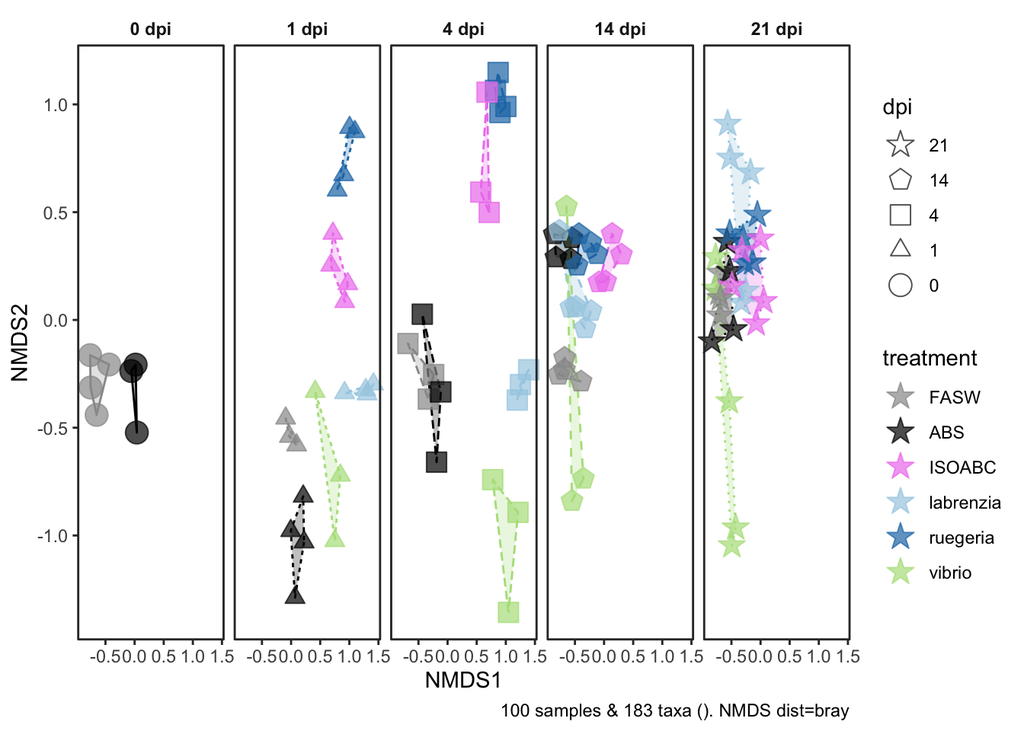

```r
dpi_labels<-c('0'="0 dpi",'1'="1 dpi","4"="4 dpi","14"="14 dpi","21"="21 dpi")

n_s1 <- nmds.mod %>%
ord_plot(shape=NA) +
theme_bw() +
stat_chull(
mapping = aes(colour = treatment, linetype = dpi, fill = treatment),
linewidth = 0.5, alpha = 0.25, show.legend = FALSE) +
geom_star(mapping = aes(color = treatment, fill = treatment, starshape = dpi),
size = 4, alpha = 0.7) +
  scale_fill_manual(values = myPal) +
scale_color_manual(values = myPal) +
scale_starshape_manual(
values = c(
"0" = 15,
"1"= 11,
"4"= 13,
"14" = 5,
"21" = 1
),
guide = guide_legend(reverse = TRUE)
) +
  facet_grid(~ dpi,
             labeller = labeller(dpi = dpi_labels)) +
   theme(
    strip.background = element_blank(),
    strip.text       = element_text(face = "bold"),
    panel.grid.major = element_blank(),
    panel.grid.minor = element_blank()
  )
n_s1
```

#### 3.1.1.2 PERMANOVA

```r
permanova<-ps.analysis %>%
  dist_calc("bray") %>%
  dist_permanova(
    variables = c("treatment","dpi","treatment:dpi"),
    n_perms = 9999,
    seed = 1392, complete_cases = TRUE, verbose = "max"
  )
```

```
## Dropping samples with missings: 0
```

```
## 2026-10-13 16:37:17.965316 - Starting PERMANOVA with 9999 perms with 1 processes
```

```
## 2026-10-13 16:37:23.600867 - Finished PERMANOVA
```

Significant interaction between treatment and time, suggests priority effects of microbial treatments

```r
print(permanova)
```

```
## psExtra object - a phyloseq object with extra slots:
##
## phyloseq-class experiment-level object
## otu_table()   OTU Table:         [ 183 taxa and 100 samples ]
## sample_data() Sample Data:       [ 100 samples by 11 sample variables ]
## tax_table()   Taxonomy Table:    [ 183 taxa by 7 taxonomic ranks ]
##
##
## bray distance matrix of size 100
## 0.4391278 0.6131637 0.5128205 0.7793257 0.6969513 ...
##
## permanova:
## Permutation test for adonis under reduced model
## Marginal effects of terms
## Permutation: free
## Number of permutations: 9999
##
## vegan::adonis2(formula = formula, data = metadata, permutations = n_perms, by = by, parallel = parall)
##               Df SumOfSqs      R2      F Pr(>F)
## treatment:dpi 16    9.313 0.27399 4.6139  1e-04 ***
## Residual      74    9.335 0.27465
## Total         99   33.991 1.00000
## ---
## Signif. codes:  0 '***' 0.001 '**' 0.01 '*' 0.05 '.' 0.1 ' ' 1
```

#### 3.1.1.3 Betadispersion

“do some treatment × dpi combinations have more variable communities than others?”

```r
dist<-dist_get(nmds.mod)
groups<-interaction(nmds.mod@sam_data$treatment, nmds.mod@sam_data$dpi)
bd <- betadisper(dist, groups, sqrt.dist = T)
anova(bd)          # overall test
```

```
## Analysis of Variance Table
##
## Response: Distances
##           Df  Sum Sq  Mean Sq F value    Pr(>F)
## Groups    25 0.70932 0.028373  2.6952 0.0005299 ***
## Residuals 74 0.77901 0.010527
## ---
## Signif. codes:  0 '***' 0.001 '**' 0.01 '*' 0.05 '.' 0.1 ' ' 1
```

```r
permutest(bd)      # permutation-based, more robust
```

```
##
## Permutation test for homogeneity of multivariate dispersions
## Permutation: free
## Number of permutations: 999
##
## Response: Distances
##           Df  Sum Sq  Mean Sq      F N.Perm Pr(>F)
## Groups    25 0.70932 0.028373 2.6952    999  0.002 **
## Residuals 74 0.77901 0.010527
## ---
## Signif. codes:  0 '***' 0.001 '**' 0.01 '*' 0.05 '.' 0.1 ' ' 1
```

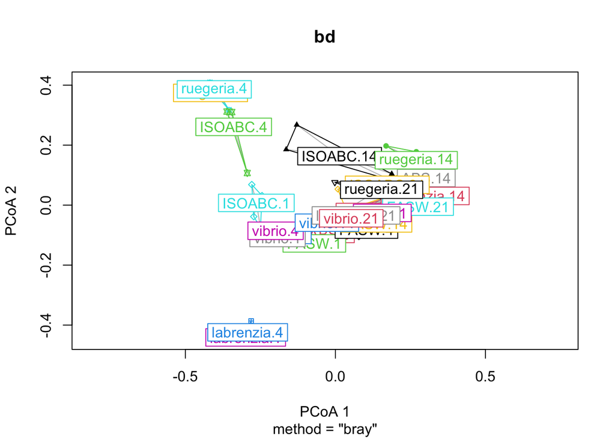

```r
plot(bd)
```

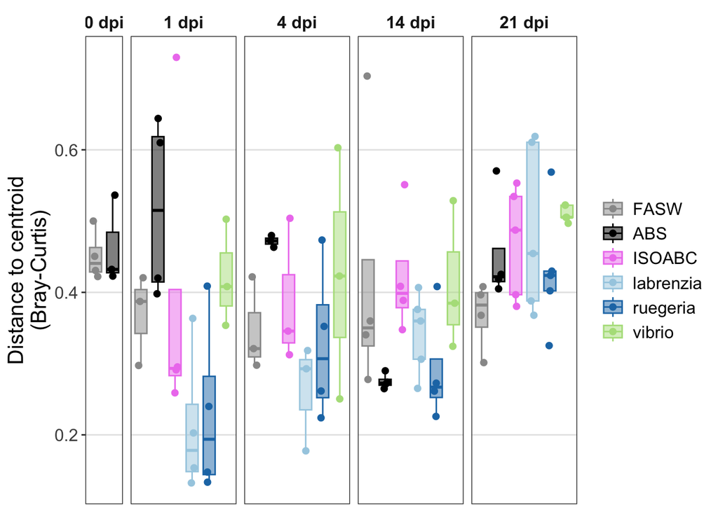

```r
# distance to centroid per sample + metadata
bd_df <- data.frame(sample_id = names(bd$distances),
                    dist_to_centroid = bd$distances) %>%
  left_join(data.frame(sample_data(nmds.mod)) %>% rownames_to_column("sample_id"),
            by = "sample_id") %>%
  mutate(dpi = factor(as.character(dpi), levels = c("0", "1", "4", "14", "21")),
         treatment = factor(as.character(treatment),
                            levels = c("FASW", "ABS", "ISOABC", "labrenzia", "ruegeria", "vibrio")))

dpi_labels_bd <- c("0" = "0 dpi", "1" = "1 dpi", "4" = "4 dpi", "14" = "14 dpi", "21" = "21 dpi")

bd_plot <- ggplot(bd_df, aes(x = treatment, y = dist_to_centroid, fill = treatment, color = treatment)) +
  geom_boxplot(alpha = 0.5, outlier.shape = NA, width = 0.7) +
  geom_jitter(width = 0.15, height = 0, size = 1.8) +
  facet_grid(~ dpi, scales = "free_x", space = "free_x",
             labeller = labeller(dpi = dpi_labels_bd)) +
  scale_fill_manual(values = myPal) +
  scale_color_manual(values = myPal) +
  labs(x = NULL, y = "Distance to centroid\n(Bray-Curtis)") +
  theme_new +
  theme(axis.text.x = element_blank(),
        axis.ticks.x = element_blank(),
        panel.grid.major.x = element_blank(),
        panel.grid.minor = element_blank(),
        strip.background = element_blank(),
        strip.text = element_text(face = "bold"),
        legend.title = element_blank())
bd_plot
```

# 4 ANCOM-BC2 Analysis

Runs a differential abundance analysis comparing the abundance of each ASV between the ABS samples and the treatment samples across each timepoint (1, 4, 14 and 21 dpi)

## 4.1 Set up analysis

```r
library(ANCOMBC)
ps.analysis<-ps.exp %>% ps_filter(dpi != "-1")
treatments_ancom <- c("labrenzia", "ruegeria", "vibrio", "ISOABC")
timepoints_ancom <- c("1dpi", "4dpi", "14dpi", "21dpi")
```

## 4.2 run analysis

compares each treatment to ABS conditions at each time point

```r
ancom_results <- list()

for (tp in timepoints_ancom) { #loops timepoints
  for (trt in treatments_ancom) { #loops treatments

     # subset to ABS + focal treatment
    ps.sub <- ps.analysis %>%
      ps_filter(treatment %in% c("ABS", trt)) %>%
      ps_filter(timepoint == tp) %>%
      tax_filter(min_prevalence = 0.1)  # remove taxa present in < 10% of samples

    # skip small groups
    grp_sizes <- table(sample_data(ps.sub)$treatment)
    if (any(grp_sizes < 2)) next

    # run ANCOM-BC2
    res <- ancombc2(
      data          = ps.sub,
      tax_level     = NULL,
      fix_formula   = "treatment",
      p_adj_method  = "BH",
      group         = "treatment",
      struc_zero    = F,
      neg_lb        = TRUE,
      verbose       = FALSE,
      pseudo        = TRUE,
      pseudo_sens   = TRUE
    )

    # rename treatment-specific columns to generic names
    res_df <- res$res %>%
      dplyr::select(
        taxon,
        lfc        = paste0("lfc_treatment", trt),
        se         = paste0("se_treatment", trt),
        W          = paste0("W_treatment", trt),
        p          = paste0("p_treatment", trt),
        q          = paste0("q_treatment", trt),
        diff       = paste0("diff_treatment", trt),
        passed_ss  = paste0("passed_ss_treatment", trt)
      ) %>%
      mutate(timepoint  = tp,
             comparison = paste0(trt, "_vs_ABS"))

    ancom_results[[paste(tp, trt)]] <- res_df
  }
}
```

```
## Proportional min_prevalence given: 0.1 --> min 1/9 samples.
```

[output not shown]

```
## Proportional min_prevalence given: 0.1 --> min 1/8 samples.
```

[output not shown]

```
## Proportional min_prevalence given: 0.1 --> min 1/9 samples.
```

[output not shown]

```
## Proportional min_prevalence given: 0.1 --> min 1/8 samples.
```

[output not shown]

```
## Proportional min_prevalence given: 0.1 --> min 1/6 samples.
```

[output not shown]

```
## Proportional min_prevalence given: 0.1 --> min 1/7 samples.
```

[output not shown]

[output not shown]

```
## Proportional min_prevalence given: 0.1 --> min 1/6 samples.
```

[output not shown]

```
## Proportional min_prevalence given: 0.1 --> min 1/9 samples.
```

[output not shown]

```
## Proportional min_prevalence given: 0.1 --> min 1/8 samples.
```

[output not shown]

```
## Proportional min_prevalence given: 0.1 --> min 1/7 samples.
```

[output not shown]

```
## Proportional min_prevalence given: 0.1 --> min 1/8 samples.
```

[output not shown]

```
## Proportional min_prevalence given: 0.1 --> min 1/9 samples.
```

[output not shown]

[output not shown]

[output not shown]

[output not shown]

```r
ancom_results_df <- bind_rows(ancom_results)

# significant hits
ancom_sig <- ancom_results_df %>% filter(diff == TRUE)
ancom_sig %>% arrange(comparison, timepoint, q)
```

```
##     taxon        lfc        se          W            p            q diff
## 1   ASV43  -7.395489 0.7344403 -10.069558 5.567430e-05 2.513820e-03 TRUE
## 2   ASV92   7.587062 0.7568871  10.024035 5.713227e-05 2.513820e-03 TRUE
## 3   ASV13  -5.856718 0.6645732  -8.812751 1.185002e-04 2.607004e-03 TRUE
## 4   ASV31   7.142548 0.7934437   9.001959 1.051424e-04 2.607004e-03 TRUE
## 5    ASV7  -8.325180 1.0420233  -7.989437 2.049615e-04 3.607323e-03 TRUE
## 6   ASV11   8.045238 1.2069204   6.665923 5.514634e-04 8.088129e-03 TRUE
## 7   ASV14   8.462491 1.3272288   6.376061 6.994865e-04 8.793544e-03 TRUE
## 8    ASV9  -7.389063 1.3311968  -5.550692 1.445173e-03 1.551914e-02 TRUE
## 9   ASV44  -4.589803 0.8421446  -5.450136 1.587185e-03 1.551914e-02 TRUE
## 10  ASV14   7.903755 0.8281197   9.544218 7.552358e-05 6.192934e-03 TRUE
## 11  ASV26   6.645548 0.9681942   6.863859 2.389806e-04 7.419632e-03 TRUE
## 12  ASV32   6.213473 0.8976490   6.921941 2.268183e-04 7.419632e-03 TRUE
## 13  ASV35  -5.635848 0.8605650  -6.549010 3.191240e-04 7.419632e-03 TRUE
## 14  ASV39   7.191223 1.0705272   6.717459 2.730258e-04 7.419632e-03 TRUE
```

[output cut: 143 more lines]

## 4.3 visualize

```r
# join taxonomy to get genus names instead of ASV IDs
tax_df <- tax_table(ps.analysis) %>%
  as.data.frame() %>%
  rownames_to_column("taxon") %>%
  dplyr::select(taxon, Species)

ancom_sig_2 <- ancom_sig %>%
  left_join(tax_df, by = "taxon") %>%
  mutate(
    sig_label = case_when(
      q < 0.001 ~ "***",
      q < 0.01  ~ "**",
      q < 0.05  ~ "*",
      TRUE      ~ ""
    ),
    direction = ifelse(lfc > 0, "Enriched vs ABS", "Depleted vs ABS")
  ) %>%
   mutate(Species_short = gsub("\\(.*\\)", "", Species),   # drop accession
         Species_short = gsub("_A$|_B$", "", Species_short),  # drop _A/_B suffixes if unwanted
         Species_short = trimws(Species_short))
```

```r
#reorder species, treatments and timepoints
sig_species <- unique(ancom_sig_2$Species_short)
priority_species<-c("Roseibium aggregatum_A_ISOA","Epibacterium mobile_ISOB","Vibrio alginolyticus_ISOC")

other_species  <- sort(setdiff(unique(ancom_sig_2$Species_short), priority_species))
ancom_sig_2   <- ancom_sig_2 %>%
  mutate(Species_short = factor(Species_short, levels = rev(c(priority_species, other_species)))) %>%
  mutate(timepoint=factor(timepoint, levels=c('1dpi','4dpi','14dpi','21dpi'),ordered=T),
         comparison=factor(comparison,levels=c("ISOABC_vs_ABS","labrenzia_vs_ABS", "ruegeria_vs_ABS",  "vibrio_vs_ABS"),ordered=T)) %>%
  mutate(comparison2=recode(comparison, 'ISOABC_vs_ABS'='ISOABC','labrenzia_vs_ABS'='Labrenzia','ruegeria_vs_ABS'='Ruegeria','vibrio_vs_ABS'='Vibrio'))
```

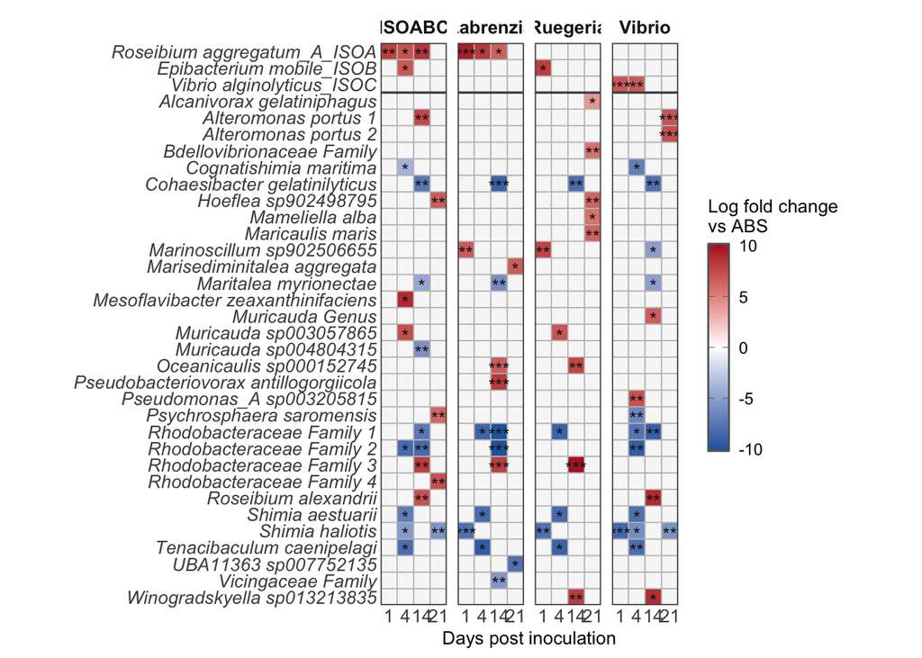

```r
# ANCOM was run on ASVs, so several ASVs can share a name (e.g. "Rhodobacteraceae Family");
# number them so each ASV gets its own row instead of overlapping
taxon_labels <- ancom_sig_2 %>%
  distinct(taxon, Species_short) %>%
  group_by(Species_short) %>%
  mutate(label = if (n() > 1) paste0(Species_short, " ", row_number()) else as.character(Species_short)) %>%
  ungroup()

# inoculant species shown first, in this order
heat_priority <- c("Roseibium aggregatum_A_ISOA", "Epibacterium mobile_ISOB", "Vibrio alginolyticus_ISOC")

label_levels <- taxon_labels %>%
  mutate(prio_order = match(as.character(Species_short), heat_priority)) %>%
  arrange(is.na(prio_order), prio_order, label) %>%
  pull(label)

# fill in every species x timepoint x treatment cell so the full grid is drawn
# (cells that were not significant stay empty/grey)
heat_df <- ancom_sig_2 %>%
  left_join(taxon_labels, by = c("taxon", "Species_short")) %>%
  dplyr::select(label, timepoint, comparison2, lfc, sig_label) %>%
  mutate(label = factor(label, levels = rev(label_levels)),
         timepoint = factor(as.character(timepoint), levels = c("1dpi", "4dpi", "14dpi", "21dpi"))) %>%
  complete(label, timepoint, comparison2)

# symmetric colour limits so 0 sits at white
lfc_max <- max(abs(heat_df$lfc), na.rm = TRUE)

# line separating the inoculant species (top) from the rest
n_other <- sum(!as.character(taxon_labels$Species_short) %in% heat_priority)

diff_taxa <- ggplot(heat_df, aes(x = timepoint, y = label, fill = lfc)) +
  geom_tile(color = "gray75", linewidth = 0.3) +
  geom_text(aes(label = sig_label), size = 3.5, vjust = 0.75, color = "gray10", na.rm = TRUE) +
  geom_hline(yintercept = n_other + 0.5, linewidth = 0.6, color = "gray30") +
  facet_grid(~ comparison2) +
  scale_fill_gradient2(
    low = "#2166AC", mid = "white", high = "#B2182B", midpoint = 0,
    limits = c(-lfc_max, lfc_max), na.value = "gray97",
    name = "Log fold change\nvs ABS",
    guide = guide_colorbar(barheight = unit(4, "cm"), barwidth = unit(0.4, "cm"),
                           frame.colour = "gray40", ticks.colour = "gray40")
  ) +
  scale_x_discrete(labels = c("1dpi" = "1", "4dpi" = "4", "14dpi" = "14", "21dpi" = "21"),
                   expand = c(0, 0)) +
  scale_y_discrete(expand = c(0, 0)) +
  coord_fixed() +
  labs(x = "Days post inoculation", y = NULL) +
  theme_new +
  theme(
    panel.grid       = element_blank(),
    panel.border     = element_rect(color = "gray30", fill = NA, linewidth = 0.6),
    panel.spacing    = unit(6, "pt"),
    axis.ticks       = element_blank(),
    axis.text.y      = element_text(size = 10, face = "italic"),
    axis.text.x      = element_text(size = 10),
    axis.title.x     = element_text(size = 10),
    strip.text       = element_text(face = "bold", size = 10),
    strip.background = element_blank(),
    legend.title     = element_text(size = 10),
    legend.text      = element_text(size = 9)
  )
diff_taxa
```

- This is plotting the deferentially abundant taxa as logfold 2 change between treatment and ABS where red is higher in treatment and blue is higher in ABS samples for each timepoint - ISOABC vs. ABS: both labrenzia (Roseibium) and ruegeria (Epibacterium) came up as being diff abund at start of experiment, do not see diff abundance of vibrio –> labrenzia and ruegeria did a good job at outcompeting vibrio for space - Labrenzia -> diff abundant during 1, 4 and 14 dpi - Ruegeria -> diff abundnace at 1 dpi, nr of taxa that diff abudnnace in tratment at end of experiment, including: - Alcanivoraz - Bdellovibrionaceae family - Hoeflea - Mamelilla alba - Marcaulis maris - Vibrio -> diff abundance at 1 and 4 dpi - at end of expeirment, altermonas portus diff abundance - In all inoculation vs. abs samples, acorss most timepoints see sig depletion of Shimia species, including shimia aestuarii, s. haliotis

# 5 Barplot

```r
# set taxon order: inoculants first, then remaining by abundance
all_taxa      <- tax_table(ps.relAbund)[, "Species"] %>%
  as.data.frame() %>% pull(Species) %>% unique()
other_taxa    <- setdiff(all_taxa, priority_species)
tax_order     <- c(priority_species, other_taxa)

# clean facet labels
trt_labels <- c(
  "ABS"       = "ABS",
  "labrenzia" = "Labrenzia",
  "ruegeria"  = "Ruegeria",
  "vibrio"    = "Vibrio",
  "ISOABC"    = "All Three"
)
tp_labels <- c(
  "post_priming" = "Pre-ABS",
  "post_ABS"     = "Post-ABS",
  "1dpi"         = "1 dpi",
  "4dpi"         = "4 dpi",
  "14dpi"        = "14 dpi",
  "21dpi"        = "21 dpi"
)
```

[figure not shown]

```r
library(ggh4x)

bar<-ps.relAbund %>%
  ps_filter(timepoint %in% c("1dpi", "4dpi", "14dpi", "21dpi")) %>%
  ps_mutate(
    dpi      = as.factor(dpi),
    timepoint = factor(timepoint, levels = c("1dpi", "4dpi", "14dpi", "21dpi"))
  ) %>%
  tax_sort(by = sum, at = "Species") %>%
  comp_barplot(tax_level = 'Species', n_taxa = 30,
               merge_other = FALSE,
               other_name  = "Other",
               x           = 'sample.names',
               tax_order   = tax_order) +
  facet_nested(.~treatment + timepoint,
               scales   = 'free', space = "free",
               labeller = labeller(treatment = trt_labels,
                                   timepoint = tp_labels)) +
  theme(
    #axis.text.y      = element_blank(),
    #axis.ticks.y     = element_blank(),
    strip.text       = element_text(size = 9, face = "bold"),
    #strip.background = element_blank(),
    panel.spacing    = unit(0.2, "lines")
  ) +
  ylab('Relative Abundance') + xlab('')
bar
```

# 6 Figures

```r
library(patchwork)
```

## 6.1 Main Figures

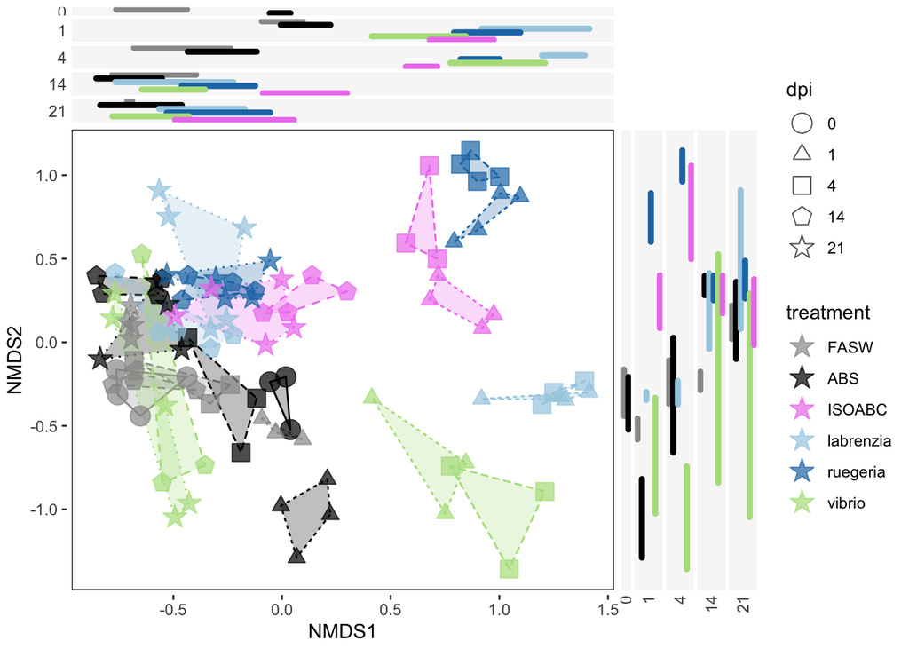

```r
n1_sidebars
```

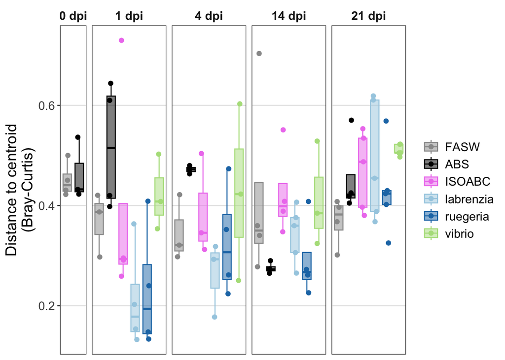

```r
ggsave(file.path(path.out,'Fig3.svg'),width=8, height=6,units = "in" )
bd_plot
```

```r
ggsave(file.path(path.out,'FigS2.svg'),width=11, height=6,units = "in" )
```

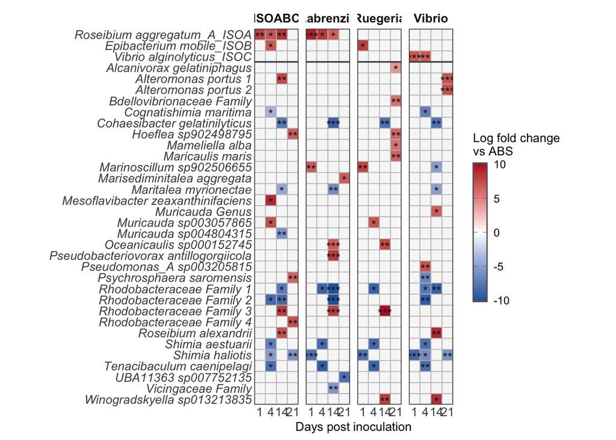

```r
diff_taxa
```

```r
ggsave(file.path(path.out,'Fig4.svg'),width=10, height=8,units = "in" )
```

[figure not shown]

```r
bar
```

```r
ggsave(file.path(path.out,'FigS1.svg'),units = 'in',width = 16,height=7)
```

## 6.2 Supplemental figures

### 6.2.1 nmds faceted plot

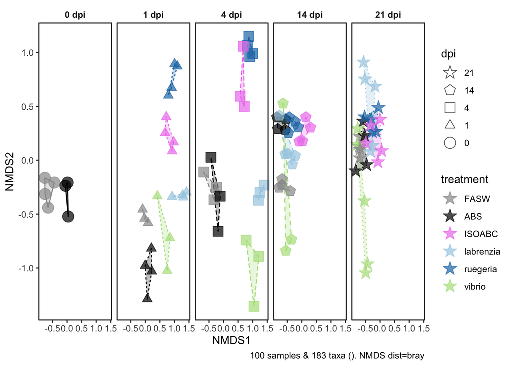

```r
n_s1
```

```r
ggsave(file.path(path.out,'FigS3.pdf'),units = 'in',width = 8,height=4)
```